# econ430-co2-agriculture

```python
# Imports
import numpy as np
import pandas as pd
import matplotlib.pyplot as plt
import seaborn as sns
from numpy import random; random.seed(10) # pre-setting seed
from scipy import stats
from scipy.stats import norm, chi2, f

# For model fitting
import statsmodels.api as sm
import statsmodels.stats.api as sms
import statsmodels.formula.api as smf

# For panel data models
!pip install linearmodels
from linearmodels.panel import PanelOLS, PooledOLS, RandomEffects # BetweenOLS
from linearmodels.panel import compare # displaying panel data models

# For seemingly unrelated regression
from collections import OrderedDict
from linearmodels.system import SUR

# For R kernel
# Note: need working copy of R, initiate chunk with `%%R`
import rpy2.ipython
%load_ext rpy2.ipython
```

[output not shown]

```python
from google.colab import files
data = files.upload()  # Opens a file picker to upload files
```

Upload widget is only available when the cell has been executed in the current browser session. Please rerun this cell to enable.

```
Saving Climate_Change_and_Agriculture.csv to Climate_Change_and_Agriculture.csv
```

```python
data2= pd.read_csv('Climate_Change_and_Agriculture.csv')
data2.info()
```

```
<class 'pandas.core.frame.DataFrame'>
RangeIndex: 620 entries, 0 to 619
Data columns (total 15 columns):
 #   Column                Non-Null Count  Dtype
---  ------                --------------  -----
 0   Year                  620 non-null    int64
 1   State                 620 non-null    object
 2   Yield_per_hectare     620 non-null    float64
 3   Fertilizer_consp      620 non-null    float64
 4   AnnualRainfall        620 non-null    float64
 5   Gross_irrigated_area  620 non-null    int64
 6   Cropping_intensity    620 non-null    float64
 7   Agri_credit           620 non-null    float64
 8   MaxTemp               620 non-null    float64
 9   Gross_sown_area       620 non-null    int64
 10  CO2_emission          620 non-null    float64
 11  Irrigation_Ratio      620 non-null    float64
 12  Unnamed: 12           0 non-null      float64
 13  Unnamed: 13           0 non-null      float64
 14  Unnamed: 14           1 non-null      float64
dtypes: float64(11), int64(3), object(1)
memory usage: 72.8+ KB
```

```python
# Convert to MultiIndex DataFrame
agri_panel = data2.set_index([ 'State', 'Year'])
agri_panel.head() # should have a structured format
```

| State | Year | Yield_per_hectare | Fertilizer_consp | AnnualRainfall | Gross_irrigated_area | Cropping_intensity | Agri_credit | MaxTemp | Gross_sown_area | CO2_emission | Irrigation_Ratio | Unnamed: 12 | Unnamed: 13 | Unnamed: 14 |
| --- | --- | --- | --- | --- | --- | --- | --- | --- | --- | --- | --- | --- | --- | --- |
| Andhra | 1990 | 1443.462185 | 123.2 | 1357.14 | 5370 | 119.7 | 20.9 | 26.99 | 13193 | 0.647451 | 40.703403 | NaN | NaN | NaN |
|  | 1991 | 1425.927426 | 119.4 | 1014.48 | 5378 | 119.5 | 22.5 | 27.06 | 13192 | 0.683086 | 40.767132 | NaN | NaN | 620.0 |
|  | 1992 | 1500.867568 | 114.8 | 675.09 | 5085 | 121.9 | 24.2 | 26.99 | 12754 | 0.690074 | 39.869845 | NaN | NaN | NaN |
|  | 1993 | 1593.308011 | 117.0 | 819.30 | 5020 | 122.4 | 25.4 | 27.23 | 12688 | 0.703136 | 39.564943 | NaN | NaN | NaN |
|  | 1994 | 1530.957365 | 128.9 | 833.19 | 5185 | 123.3 | 27.7 | 27.16 | 12783 | 0.725622 | 40.561683 | NaN | NaN | NaN |

```python
print(data2.shape) # dimensions
```

```
(620, 15)
```

```python
agri_p = agri_panel.drop(columns=['Unnamed: 12', 'Unnamed: 13', 'Unnamed: 14'])#dropping unnecessary empty columns
agri_p.head()
```

| State | Year | Yield_per_hectare | Fertilizer_consp | AnnualRainfall | Gross_irrigated_area | Cropping_intensity | Agri_credit | MaxTemp | Gross_sown_area | CO2_emission | Irrigation_Ratio |
| --- | --- | --- | --- | --- | --- | --- | --- | --- | --- | --- | --- |
| Andhra | 1990 | 1443.462185 | 123.2 | 1357.14 | 5370 | 119.7 | 20.9 | 26.99 | 13193 | 0.647451 | 40.703403 |
|  | 1991 | 1425.927426 | 119.4 | 1014.48 | 5378 | 119.5 | 22.5 | 27.06 | 13192 | 0.683086 | 40.767132 |
|  | 1992 | 1500.867568 | 114.8 | 675.09 | 5085 | 121.9 | 24.2 | 26.99 | 12754 | 0.690074 | 39.869845 |
|  | 1993 | 1593.308011 | 117.0 | 819.30 | 5020 | 122.4 | 25.4 | 27.23 | 12688 | 0.703136 | 39.564943 |
|  | 1994 | 1530.957365 | 128.9 | 833.19 | 5185 | 123.3 | 27.7 | 27.16 | 12783 | 0.725622 | 40.561683 |

# **Agricultural Yield Dataset Overview**

Our dataset assesses the agricultural yield per hectare in India across 20 Indian States and 31 years. The primary aim is to measure the impact of Greenhouse Gases (GHGs), particularly CO2, on crop yield.

In certain cases, increased CO2 levels can initially stimulate plant growth, leading to higher yields for specific crops. The analyses and tests conducted below aim to substantiate this claim and help identify the best model to study the effect of CO2 on agricultural yield.

## **Variables in the Dataset**

- **'Yield_per_hectare':** Yield in kilometers.
- **'Fertilizer_consp':** Fertilizer consumption in kilograms per kilometer.
- **'AnnualRainfall':** Annual rainfall in mm².
- **'Gross_irrigated_area':** Gross irrigated area in km².
- **'Cropping_intensity':** Crop density.
- **'Agri_credit':** Agricultural loans provided.
- **'MaxTemp':** Maximum temperature in the area (°C).
- **'Gross_sown_area':** Gross sown area in km².
- **'CO2_emission':** CO2 emissions in metric tonnes.
- **'Irrigation_Ratio':** Ratio of irrigated to non-irrigated land.

## Descriptive Analysis

```python
#five number summary
agri_p.describe()
```

|  | Yield_per_hectare | Fertilizer_consp | AnnualRainfall | Gross_irrigated_area | Cropping_intensity | Agri_credit | MaxTemp | Gross_sown_area | CO2_emission | Irrigation_Ratio |
| --- | --- | --- | --- | --- | --- | --- | --- | --- | --- | --- |
| count | 620.000000 | 620.000000 | 620.000000 | 620.000000 | 620.000000 | 6.200000e+02 | 620.000000 | 620.000000 | 620.000000 | 620.000000 |
| mean | 2279.942238 | 106.568177 | 1415.882968 | 3552.667742 | 150.787742 | 1.785492e+02 | 22.599677 | 9595.329032 | 1.133496 | 37.682012 |
| std | 1136.544701 | 81.413580 | 722.812235 | 3079.066305 | 41.496182 | 3.203585e+02 | 7.522449 | 8599.302683 | 0.374422 | 22.763926 |
| min | 503.350231 | 0.600000 | 201.510000 | 38.000000 | 100.000000 | 1.000000e-07 | -3.300000 | 187.000000 | 0.647451 | 3.595847 |
| 25% | 1430.863615 | 47.400000 | 899.930000 | 435.500000 | 121.900000 | 8.277500e+00 | 23.700000 | 2225.750000 | 0.817360 | 20.877002 |
| 50% | 1968.481335 | 85.700000 | 1197.275000 | 3509.000000 | 139.300000 | 3.080000e+01 | 25.315000 | 7864.500000 | 0.984261 | 31.451964 |
| 75% | 2825.427005 | 150.450000 | 1845.655000 | 5674.000000 | 170.525000 | 1.887500e+02 | 26.070000 | 12878.000000 | 1.527674 | 48.296870 |
| max | 6505.000000 | 494.600000 | 3718.890000 | 18424.000000 | 312.900000 | 1.980530e+03 | 28.230000 | 35615.000000 | 1.795595 | 99.055742 |

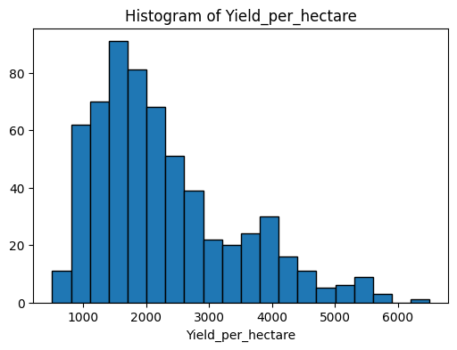

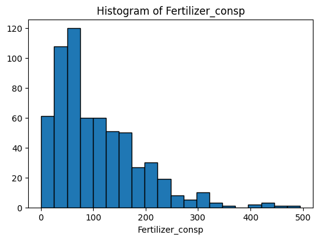

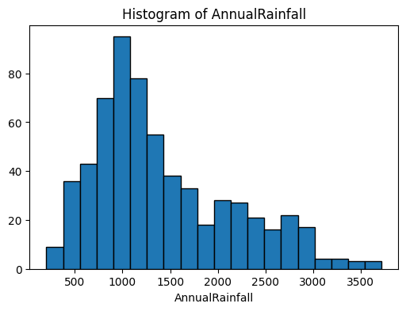

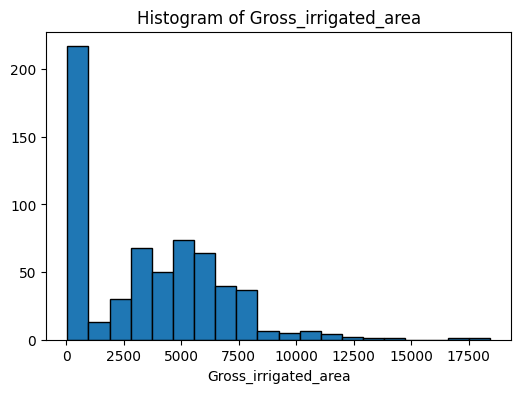

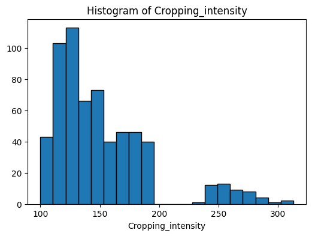

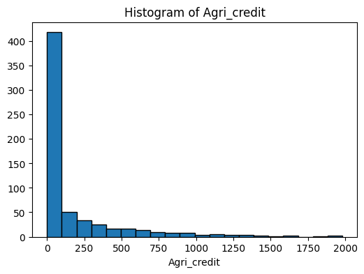

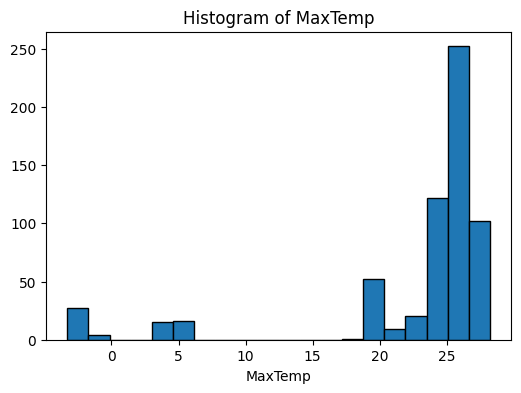

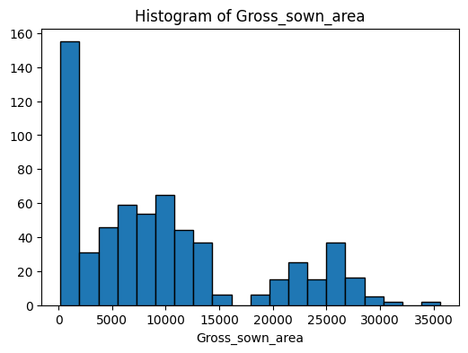

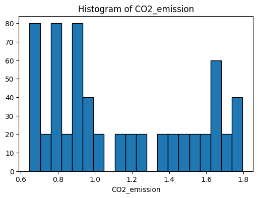

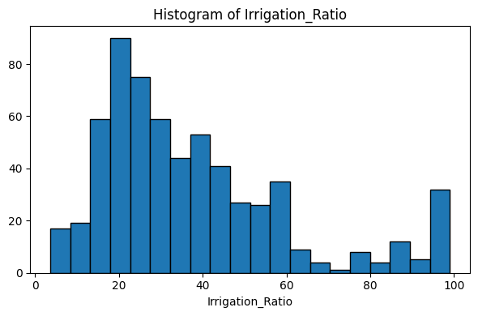

```python
#histograms
variables = [
    'Yield_per_hectare',
    'Fertilizer_consp',
    'AnnualRainfall',
    'Gross_irrigated_area',
    'Cropping_intensity',
    'Agri_credit',
    'MaxTemp',
    'Gross_sown_area',
    'CO2_emission',
    'Irrigation_Ratio'
]


for var in variables:
    plt.figure(figsize=(6, 4))
    plt.hist(agri_p[var], bins=20, edgecolor='k')
    plt.title(f'Histogram of {var}')
    plt.xlabel(var)


plt.tight_layout()
plt.show()
```

### Data Distribution Analysis

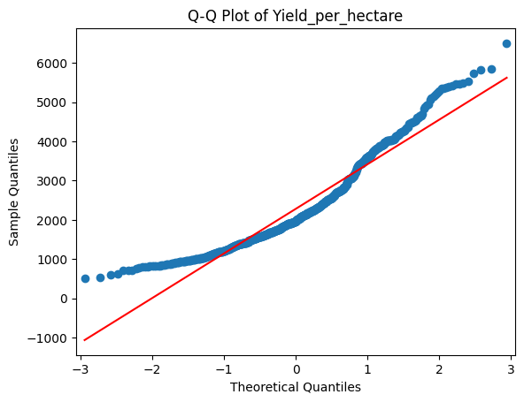

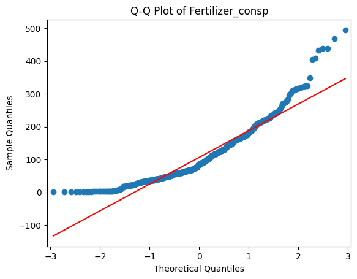

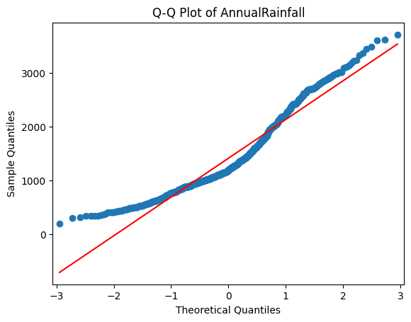

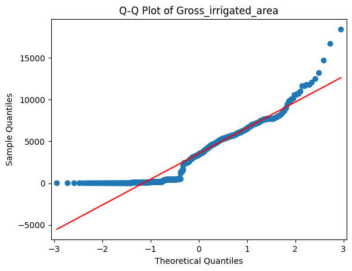

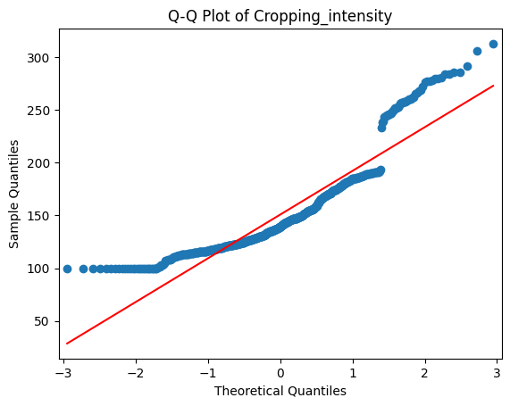

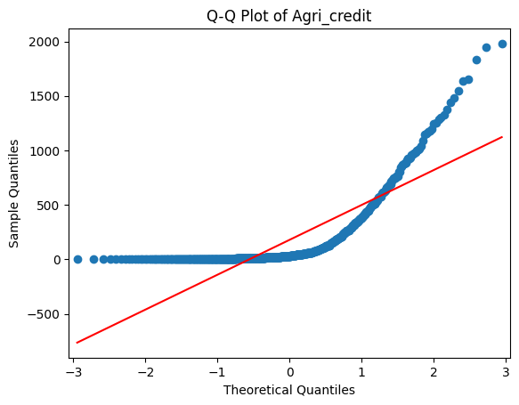

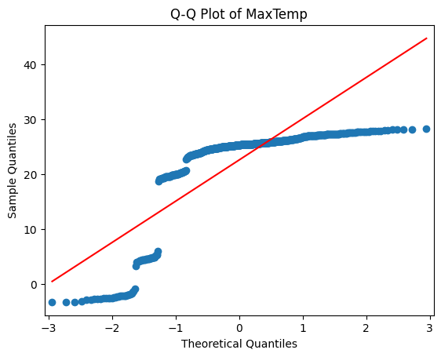

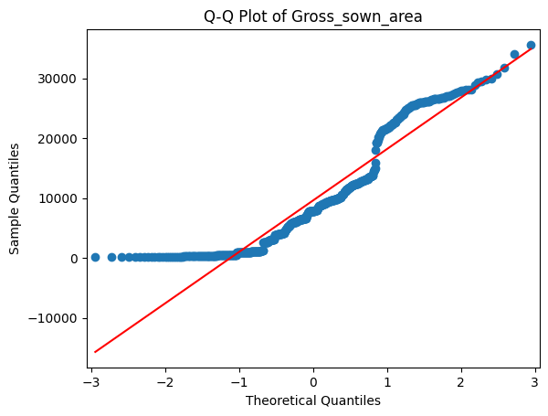

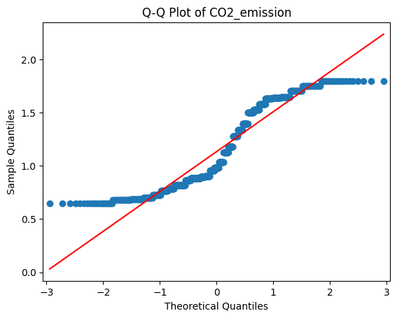

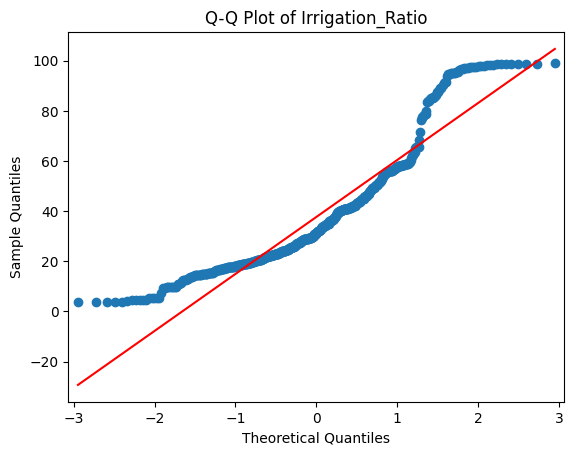

```python
#fitted distributions

for var in variables:
    plt.figure(figsize=(6, 4))
    sm.qqplot(agri_p[var], line='s')
    plt.title(f'Q-Q Plot of {var}')
    plt.show()
```

### Data Distribution Analysis

```
                      Yield_per_hectare  Fertilizer_consp  AnnualRainfall  \
Yield_per_hectare              1.000000          0.634371        0.123195
Fertilizer_consp               0.634371          1.000000       -0.394567
AnnualRainfall                 0.123195         -0.394567        1.000000
Gross_irrigated_area           0.247411          0.602336       -0.609182
Cropping_intensity             0.520243          0.502156       -0.152351
Agri_credit                    0.390858          0.604873       -0.197185
MaxTemp                        0.147340          0.289036       -0.004595
Gross_sown_area               -0.028293          0.353336       -0.481510
CO2_emission                   0.399431          0.363248        0.001426
Irrigation_Ratio               0.375681          0.552012       -0.502576

                      Gross_irrigated_area  Cropping_intensity  Agri_credit  \
Yield_per_hectare                 0.247411            0.520243     0.390858
Fertilizer_consp                  0.602336            0.502156     0.604873
AnnualRainfall                   -0.609182           -0.152351    -0.197185
Gross_irrigated_area              1.000000            0.472688     0.444753
Cropping_intensity                0.472688            1.000000     0.236917
Agri_credit                       0.444753            0.236917     1.000000
MaxTemp                           0.448627           -0.031498     0.253800
Gross_sown_area                   0.760172            0.220810     0.350939
CO2_emission                      0.191560            0.257829     0.618953
Irrigation_Ratio                  0.544799            0.370973     0.195199

                       MaxTemp  Gross_sown_area  CO2_emission  \
Yield_per_hectare     0.147340        -0.028293      0.399431
Fertilizer_consp      0.289036         0.353336      0.363248
AnnualRainfall       -0.004595        -0.481510      0.001426
Gross_irrigated_area  0.448627         0.760172      0.191560
Cropping_intensity   -0.031498         0.220810      0.257829
Agri_credit           0.253800         0.350939      0.618953
MaxTemp               1.000000         0.433461      0.028990
Gross_sown_area       0.433461         1.000000      0.038116
CO2_emission          0.028990         0.038116      1.000000
Irrigation_Ratio      0.118235        -0.032258      0.137325

                      Irrigation_Ratio
Yield_per_hectare             0.375681
Fertilizer_consp              0.552012
AnnualRainfall               -0.502576
Gross_irrigated_area          0.544799
Cropping_intensity            0.370973
Agri_credit                   0.195199
MaxTemp                       0.118235
Gross_sown_area              -0.032258
CO2_emission                  0.137325
Irrigation_Ratio              1.000000
```

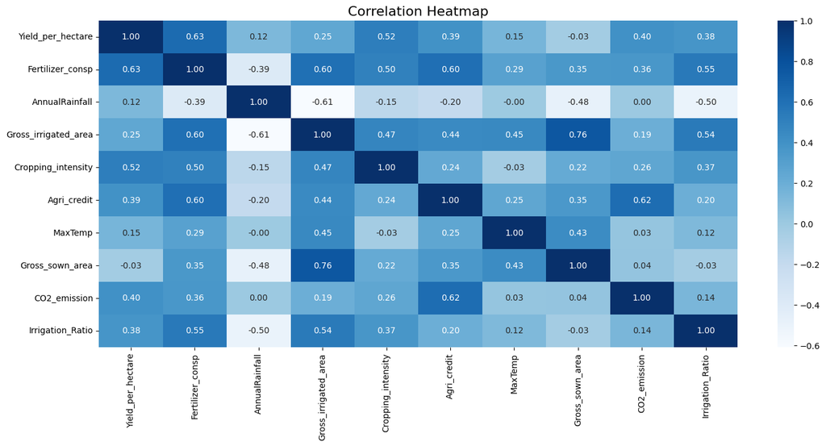

```python
#correlation plot
C = agri_p[['Yield_per_hectare',
              'Fertilizer_consp',
              'AnnualRainfall',
              'Gross_irrigated_area',
              'Cropping_intensity',
              'Agri_credit',
              'MaxTemp',
              'Gross_sown_area',
              'CO2_emission',
              'Irrigation_Ratio']].corr()

# Display the correlation matrix
print(C)

# Create a heatmap
plt.figure(figsize=(17, 7))
sns.heatmap(C, annot=True, cmap="Blues", fmt=".2f")

# Add title
plt.title("Correlation Heatmap", fontsize=16)
```

# **Correlation Analysis**

## **Variables with Positive Correlation**

- **Yield per hectare and Fertilizer consumption (0.63):**
  - A moderate positive correlation suggests that increasing fertilizer use is associated with an increase in yield per hectare.
- **Yield per hectare and Cropping intensity (0.52):**
  - Indicates that higher cropping intensity (e.g., multi-cropping or increased agricultural activity) is associated with better yields.
- **Fertilizer consumption and Gross irrigated area (0.60):**
  - Suggests that areas with more irrigation tend to use more fertilizers, possibly due to increased agricultural activity.
- **Gross sown area and Gross irrigated area (0.76):**
  - A strong positive correlation, indicating that areas with more sown area also tend to have higher irrigation coverage.
- **CO2 emission and Agri credit (0.62):**
  - Implies that higher agricultural credit is associated with increased CO2 emissions, possibly reflecting higher mechanization or chemical use.
- **Irrigation ratio and Fertilizer consumption (0.55):**
  - Suggests that areas with better irrigation facilities also utilize more fertilizers.

## **Variables with Negative Correlation**

- **Annual rainfall and Gross irrigated area (-0.61):**
  - A significant negative correlation indicates that areas receiving more rainfall rely less on irrigation.
- **Annual rainfall and Irrigation ratio (-0.50):**
  - Reinforces the observation that higher natural rainfall reduces dependence on artificial irrigation.
- **Gross sown area and Annual rainfall (-0.48):**
  - Indicates that areas with higher sown area might not always align with high rainfall regions, potentially relying on irrigation instead.

## **Weak Correlations**

- **Yield per hectare and Annual rainfall (0.12):**
  - A weak correlation suggests that rainfall alone has limited influence on yield, possibly due to dependence on other factors like fertilizer or irrigation.
- **Yield per hectare and Max temperature (0.15):**
  - A weak positive relationship indicates minimal influence of temperature on yield.
- **Gross sown area and CO2 emissions (0.04):**
  - Implies negligible association between the extent of sown area and carbon emissions.

```python
import rpy2.robjects as robjects
from rpy2.robjects import pandas2ri

pd.DataFrame.iteritems = pd.DataFrame.items
```

```python
# Set things up to share objects between R and python environments
pandas2ri.activate()
# Have to convert panda dataframe to R dataframe, in this case agri_p is our pandas dataframe
r_df1 = pandas2ri.py2rpy(agri_p)


# Then stash our new R datastructure in a global envrionment we can grab later
robjects.globalenv['data_f'] = pandas2ri.py2rpy(data2)
```

```python
#Cullen-Frey Graphs
%%R
install.packages(c("fitdistrplus"))
```

```
WARNING:rpy2.rinterface_lib.callbacks:R[write to console]: Loading required package: MASS

WARNING:rpy2.rinterface_lib.callbacks:R[write to console]: Loading required package: survival
```

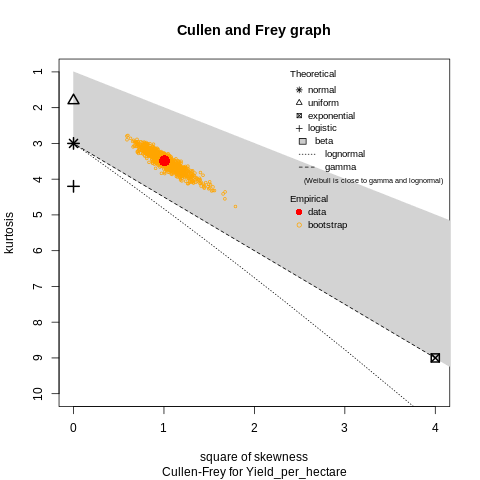

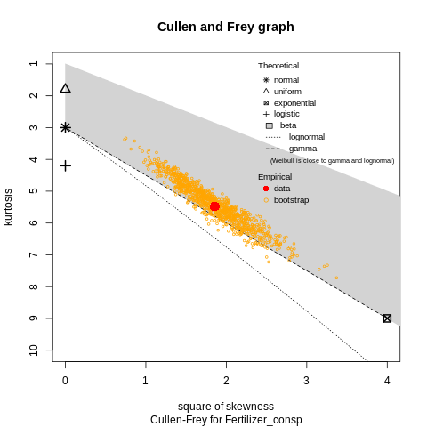

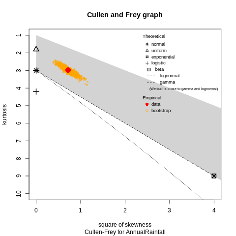

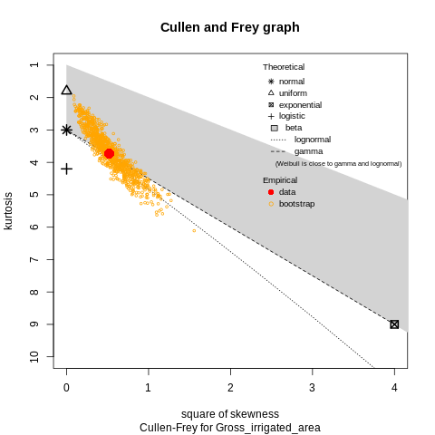

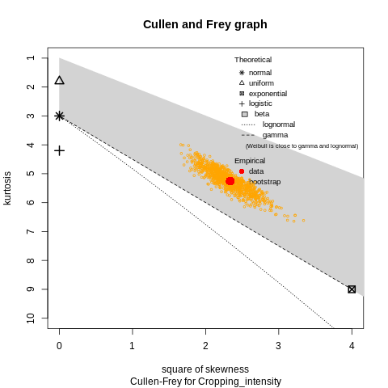

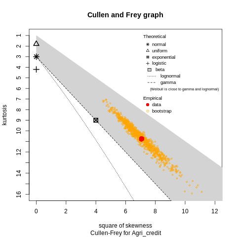

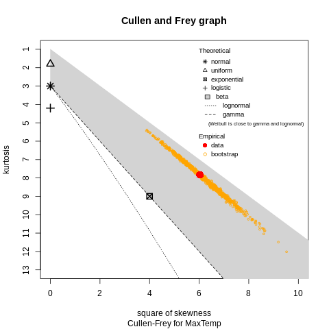

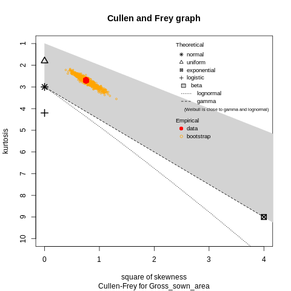

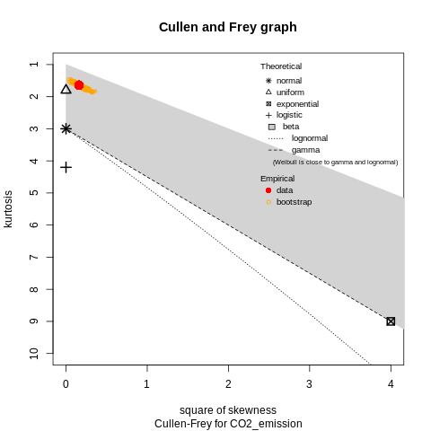

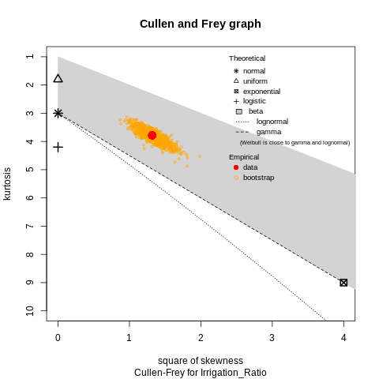

```python
%%R

library("fitdistrplus")
set.seed(10) # for bootstrap

descdist(data_f$Yield_per_hectare, boot = 1000)
title(sub = "Cullen-Frey for Yield_per_hectare")


descdist(data_f$Fertilizer_consp, boot = 1000)
title(sub = "Cullen-Frey for Fertilizer_consp")

descdist(data_f$AnnualRainfall, boot = 1000)
title(sub = "Cullen-Frey for AnnualRainfall")

descdist(data_f$Gross_irrigated_area, boot = 1000)
title(sub = "Cullen-Frey for Gross_irrigated_area")

descdist(data_f$Cropping_intensity, boot = 1000)
title(sub = "Cullen-Frey for Cropping_intensity")

descdist(data_f$Agri_credit, boot = 1000)
title(sub = "Cullen-Frey for Agri_credit")

descdist(data_f$MaxTemp, boot = 1000)
title(sub = "Cullen-Frey for MaxTemp")

descdist(data_f$Gross_sown_area, boot = 1000)
title(sub = "Cullen-Frey for Gross_sown_area")

descdist(data_f$CO2_emission, boot = 1000)
title(sub = "Cullen-Frey for CO2_emission")

descdist(data_f$Irrigation_Ratio, boot = 1000)
title(sub = "Cullen-Frey for Irrigation_Ratio")
```